# Heart_disease

```python
import pandas as pd
import numpy as np
import seaborn as sns
import matplotlib.pyplot as plt
```

```python
hd = pd.read_csv('heart.csv')
```

```python
hd.head()
```

|  | age | sex | cp | trestbps | chol | fbs | restecg | thalach | exang | oldpeak | slope | ca | thal | target |
| --- | --- | --- | --- | --- | --- | --- | --- | --- | --- | --- | --- | --- | --- | --- |
| 0 | 63 | 1 | 3 | 145 | 233 | 1 | 0 | 150 | 0 | 2.3 | 0 | 0 | 1 | 1 |
| 1 | 37 | 1 | 2 | 130 | 250 | 0 | 1 | 187 | 0 | 3.5 | 0 | 0 | 2 | 1 |
| 2 | 41 | 0 | 1 | 130 | 204 | 0 | 0 | 172 | 0 | 1.4 | 2 | 0 | 2 | 1 |
| 3 | 56 | 1 | 1 | 120 | 236 | 0 | 1 | 178 | 0 | 0.8 | 2 | 0 | 2 | 1 |
| 4 | 57 | 0 | 0 | 120 | 354 | 0 | 1 | 163 | 1 | 0.6 | 2 | 0 | 2 | 1 |

```python
hd = hd.rename(columns = {'cp':'chest_pain', 'trestbps':'resting_bp', 'chol':'cholesterol', 'fbs':'fasting_bs',
                         'thalach':'max_hr', 'exang':'exercise_angina', 'oldpeak':'ST_depression', 'thal':'defect',
                         'target':'CHD_present', 'ca':'vessels_colored'})
hd.head()
```

|  | age | sex | chest_pain | resting_bp | cholesterol | fasting_bs | restecg | max_hr | exercise_angina | ST_depression | slope | vessels_colored | defect | CHD_present |
| --- | --- | --- | --- | --- | --- | --- | --- | --- | --- | --- | --- | --- | --- | --- |
| 0 | 63 | 1 | 3 | 145 | 233 | 1 | 0 | 150 | 0 | 2.3 | 0 | 0 | 1 | 1 |
| 1 | 37 | 1 | 2 | 130 | 250 | 0 | 1 | 187 | 0 | 3.5 | 0 | 0 | 2 | 1 |
| 2 | 41 | 0 | 1 | 130 | 204 | 0 | 0 | 172 | 0 | 1.4 | 2 | 0 | 2 | 1 |
| 3 | 56 | 1 | 1 | 120 | 236 | 0 | 1 | 178 | 0 | 0.8 | 2 | 0 | 2 | 1 |
| 4 | 57 | 0 | 0 | 120 | 354 | 0 | 1 | 163 | 1 | 0.6 | 2 | 0 | 2 | 1 |

```python
hd = hd.rename(columns = {'slope':'ST_slope'})
```

```python
hd.info()
```

```
<class 'pandas.core.frame.DataFrame'>
RangeIndex: 303 entries, 0 to 302
Data columns (total 14 columns):
age                303 non-null int64
sex                303 non-null int64
chest_pain         303 non-null int64
resting_bp         303 non-null int64
cholesterol        303 non-null int64
fasting_bs         303 non-null int64
restecg            303 non-null int64
max_hr             303 non-null int64
exercise_angina    303 non-null int64
ST_depression      303 non-null float64
ST_slope           303 non-null int64
vessels_colored    303 non-null int64
defect             303 non-null int64
CHD_present        303 non-null int64
dtypes: float64(1), int64(13)
memory usage: 33.2 KB
```

```python
hd['sex'] = np.where(hd['sex'] == 1, 'M', 'F')
hd.sex.head()
```

```
0    M
1    M
2    F
3    M
4    F
Name: sex, dtype: object
```

```python
hd['CHD_present'] = np.where(hd['CHD_present'] == 1, 0, 1)
hd.CHD_present.head()
```

```
0    0
1    0
2    0
3    0
4    0
Name: CHD_present, dtype: int32
```

```python
hd['chest_pain'] = pd.Categorical(hd['chest_pain'])
hd['fasting_bs'] = hd['fasting_bs'].astype(bool)
hd['restecg'] = pd.Categorical(hd['restecg'])
hd['exercise_angina'] = hd['exercise_angina'].astype(bool)
hd['ST_slope'] = pd.Categorical(hd['ST_slope'])
hd['defect'] = pd.Categorical(hd['defect'])
hd['CHD_present'] = hd['CHD_present'].astype(bool)
```

```python
hd.info()
```

```
<class 'pandas.core.frame.DataFrame'>
RangeIndex: 303 entries, 0 to 302
Data columns (total 14 columns):
age                303 non-null int64
sex                303 non-null object
chest_pain         303 non-null category
resting_bp         303 non-null int64
cholesterol        303 non-null int64
fasting_bs         303 non-null bool
restecg            303 non-null category
max_hr             303 non-null int64
exercise_angina    303 non-null bool
ST_depression      303 non-null float64
ST_slope           303 non-null category
vessels_colored    303 non-null int64
defect             303 non-null category
CHD_present        303 non-null bool
dtypes: bool(3), category(4), float64(1), int64(5), object(1)
memory usage: 19.3+ KB
```

```python
hd.describe()
```

|  | age | resting_bp | cholesterol | max_hr | ST_depression | vessels_colored |
| --- | --- | --- | --- | --- | --- | --- |
| count | 303.000000 | 303.000000 | 303.000000 | 303.000000 | 303.000000 | 303.000000 |
| mean | 54.366337 | 131.623762 | 246.264026 | 149.646865 | 1.039604 | 0.729373 |
| std | 9.082101 | 17.538143 | 51.830751 | 22.905161 | 1.161075 | 1.022606 |
| min | 29.000000 | 94.000000 | 126.000000 | 71.000000 | 0.000000 | 0.000000 |
| 25% | 47.500000 | 120.000000 | 211.000000 | 133.500000 | 0.000000 | 0.000000 |
| 50% | 55.000000 | 130.000000 | 240.000000 | 153.000000 | 0.800000 | 0.000000 |
| 75% | 61.000000 | 140.000000 | 274.500000 | 166.000000 | 1.600000 | 1.000000 |
| max | 77.000000 | 200.000000 | 564.000000 | 202.000000 | 6.200000 | 4.000000 |

#### Since the description for resting ECG is unclear, I decided to drop it

```python
hd = hd.drop(columns = ['restecg'])
```

```python
hd.head()
```

|  | age | sex | chest_pain | resting_bp | cholesterol | fasting_bs | max_hr | exercise_angina | ST_depression | ST_slope | vessels_colored | defect | CHD_present |
| --- | --- | --- | --- | --- | --- | --- | --- | --- | --- | --- | --- | --- | --- |
| 0 | 63 | M | 3 | 145 | 233 | True | 150 | False | 2.3 | 0 | 0 | 1 | False |
| 1 | 37 | M | 2 | 130 | 250 | False | 187 | False | 3.5 | 0 | 0 | 2 | False |
| 2 | 41 | F | 1 | 130 | 204 | False | 172 | False | 1.4 | 2 | 0 | 2 | False |
| 3 | 56 | M | 1 | 120 | 236 | False | 178 | False | 0.8 | 2 | 0 | 2 | False |
| 4 | 57 | F | 0 | 120 | 354 | False | 163 | True | 0.6 | 2 | 0 | 2 | False |

```python
chest_pain_types = []
for row in hd['chest_pain']:
    if row == 1:
        chest_pain_types.append('typical_angina')
    elif row == 2:
        chest_pain_types.append('atypical_angina')
    elif row == 3:
        chest_pain_types.append('non-aginal_pain')
    else:
        chest_pain_types.append('asymptomatic')

len(chest_pain_types)
```

```
303
```

```python
hd['chest_pain'] = chest_pain_types
```

```python
hd.head()
```

|  | age | sex | chest_pain | resting_bp | cholesterol | fasting_bs | max_hr | exercise_angina | ST_depression | ST_slope | vessels_colored | defect | CHD_present |
| --- | --- | --- | --- | --- | --- | --- | --- | --- | --- | --- | --- | --- | --- |
| 0 | 63 | M | non-aginal_pain | 145 | 233 | True | 150 | False | 2.3 | 0 | 0 | 1 | False |
| 1 | 37 | M | atypical_angina | 130 | 250 | False | 187 | False | 3.5 | 0 | 0 | 2 | False |
| 2 | 41 | F | typical_angina | 130 | 204 | False | 172 | False | 1.4 | 2 | 0 | 2 | False |
| 3 | 56 | M | typical_angina | 120 | 236 | False | 178 | False | 0.8 | 2 | 0 | 2 | False |
| 4 | 57 | F | asymptomatic | 120 | 354 | False | 163 | True | 0.6 | 2 | 0 | 2 | False |

```python
slope_type = []
for row in hd['ST_slope']:
    if row == 0:
        slope_type.append('upsloping')
    elif row == 1:
        slope_type.append('flat')
    else:
        slope_type.append('downsloping')


print(len(slope_type))

hd['ST_slope'] = slope_type
hd.head()
```

```
303
```

|  | age | sex | chest_pain | resting_bp | cholesterol | fasting_bs | max_hr | exercise_angina | ST_depression | ST_slope | vessels_colored | defect | CHD_present |
| --- | --- | --- | --- | --- | --- | --- | --- | --- | --- | --- | --- | --- | --- |
| 0 | 63 | M | non-aginal_pain | 145 | 233 | True | 150 | False | 2.3 | upsloping | 0 | 1 | False |
| 1 | 37 | M | atypical_angina | 130 | 250 | False | 187 | False | 3.5 | upsloping | 0 | 2 | False |
| 2 | 41 | F | typical_angina | 130 | 204 | False | 172 | False | 1.4 | downsloping | 0 | 2 | False |
| 3 | 56 | M | typical_angina | 120 | 236 | False | 178 | False | 0.8 | downsloping | 0 | 2 | False |
| 4 | 57 | F | asymptomatic | 120 | 354 | False | 163 | True | 0.6 | downsloping | 0 | 2 | False |

```python
defect_type = []
for row in hd['defect']:
    if row == 1:
        defect_type.append('normal')
    elif row == 2:
        defect_type.append('fixed_defect')
    elif row == 3:
        defect_type.append('reversable_defect')
    else:
        defect_type.append('NaN')

hd['defect'] = defect_type
hd.head()
```

|  | age | sex | chest_pain | resting_bp | cholesterol | fasting_bs | max_hr | exercise_angina | ST_depression | ST_slope | vessels_colored | defect | CHD_present |
| --- | --- | --- | --- | --- | --- | --- | --- | --- | --- | --- | --- | --- | --- |
| 0 | 63 | M | non-aginal_pain | 145 | 233 | True | 150 | False | 2.3 | upsloping | 0 | normal | False |
| 1 | 37 | M | atypical_angina | 130 | 250 | False | 187 | False | 3.5 | upsloping | 0 | fixed_defect | False |
| 2 | 41 | F | typical_angina | 130 | 204 | False | 172 | False | 1.4 | downsloping | 0 | fixed_defect | False |
| 3 | 56 | M | typical_angina | 120 | 236 | False | 178 | False | 0.8 | downsloping | 0 | fixed_defect | False |
| 4 | 57 | F | asymptomatic | 120 | 354 | False | 163 | True | 0.6 | downsloping | 0 | fixed_defect | False |

```python
hd.isnull().sum()
```

```
age                0
sex                0
chest_pain         0
resting_bp         0
cholesterol        0
fasting_bs         0
max_hr             0
exercise_angina    0
ST_depression      0
ST_slope           0
vessels_colored    0
defect             0
CHD_present        0
dtype: int64
```

### First thing is to inspect and see if there are any strong correlations between heart disease and the other factors

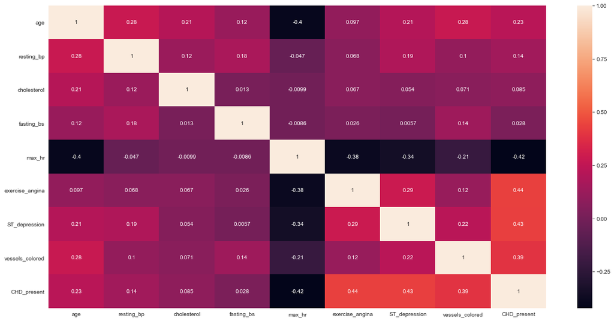

```python
plt.figure(figsize = (20, 10))
sns.heatmap(hd.corr(), annot = True)
plt.show()
```

### From just looking at the correlations the four greatest indicators of heart disease are the maximum heart rate achieved (inverted relationship), whether or not the patient experienced exercise angina, the level of ST wave depression, and the number of vessels colored in the fluoroscopy. I'm also going to look and some of the other data points and see what kind of covariance there is between them.

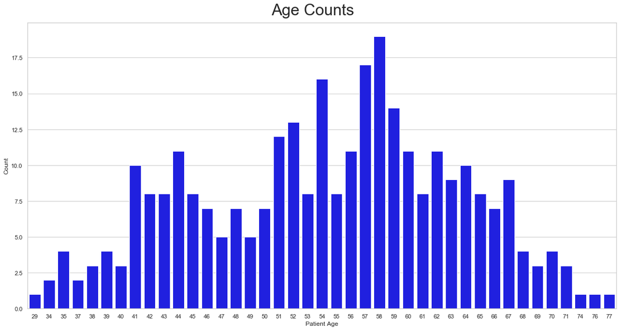

```python
plt.figure(figsize = (20, 10))
sns.barplot(x = hd.age.value_counts().index, y = hd.age.value_counts().values, color = 'blue')
plt.xlabel('Patient Age')
plt.ylabel('Count')
plt.figtext(.5, .9, 'Age Counts', fontsize = 30, ha = 'center')
plt.show()
```

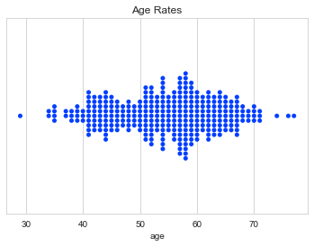

```python
sns.swarmplot(x=hd.age)
plt.title('Age Rates')
plt.show()
```

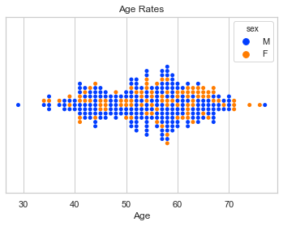

```python
#Have to create a dummy variable for y otherwise hue won't appear
sns.set_palette('bright')

sns.swarmplot(x = hd['age'], hue = hd['sex'], y = [''] *len(hd))
plt.title('Age Rates')
plt.xlabel('Age')
```

```python
hd.sex.value_counts()
```

```
M    207
F     96
Name: sex, dtype: int64
```

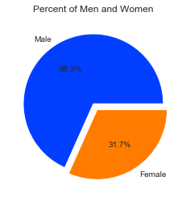

```python
plt.pie(hd.sex.value_counts(), labels = ['Male', 'Female'], autopct = '%1.1f%%', explode = [0, 0.1])
plt.title('Percent of Men and Women')
plt.show()
```

```python
hd.head()
```

|  | age | sex | chest_pain | resting_bp | cholesterol | fasting_bs | max_hr | exercise_angina | ST_depression | ST_slope | vessels_colored | defect | CHD_present |
| --- | --- | --- | --- | --- | --- | --- | --- | --- | --- | --- | --- | --- | --- |
| 0 | 63 | M | non-aginal_pain | 145 | 233 | True | 150 | False | 2.3 | upsloping | 0 | normal | False |
| 1 | 37 | M | atypical_angina | 130 | 250 | False | 187 | False | 3.5 | upsloping | 0 | fixed_defect | False |
| 2 | 41 | F | typical_angina | 130 | 204 | False | 172 | False | 1.4 | downsloping | 0 | fixed_defect | False |
| 3 | 56 | M | typical_angina | 120 | 236 | False | 178 | False | 0.8 | downsloping | 0 | fixed_defect | False |
| 4 | 57 | F | asymptomatic | 120 | 354 | False | 163 | True | 0.6 | downsloping | 0 | fixed_defect | False |

```python
print(hd.groupby('sex').age.describe())
```

```
     count       mean       std   min    25%   50%   75%   max
sex
F     96.0  55.677083  9.409396  34.0  49.75  57.0  63.0  76.0
M    207.0  53.758454  8.883803  29.0  47.00  54.0  59.5  77.0
```

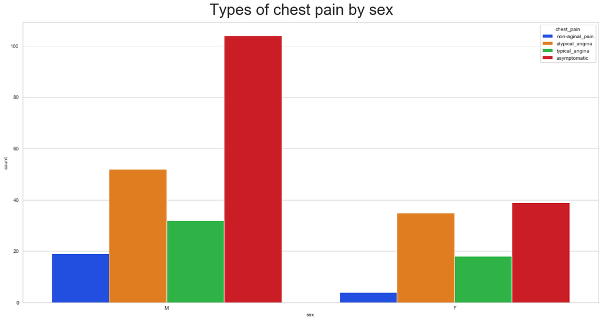

```python
plt.figure(figsize = (20,10))
sns.countplot(x = hd.sex, hue = hd.chest_pain, data = hd)
plt.figtext(.5, .9, 'Types of chest pain by sex', fontsize = 30, ha = 'center')
```

```python
print(hd.groupby('sex').chest_pain.value_counts())
print(hd.groupby('sex').chest_pain.value_counts(normalize = True))
```

```
sex  chest_pain
F    asymptomatic        39
     atypical_angina     35
     typical_angina      18
     non-aginal_pain      4
M    asymptomatic       104
     atypical_angina     52
     typical_angina      32
     non-aginal_pain     19
Name: chest_pain, dtype: int64
sex  chest_pain
F    asymptomatic       0.406250
     atypical_angina    0.364583
     typical_angina     0.187500
     non-aginal_pain    0.041667
M    asymptomatic       0.502415
     atypical_angina    0.251208
     typical_angina     0.154589
     non-aginal_pain    0.091787
Name: chest_pain, dtype: float64
```

#### It appears that a major difference in men and women is that women seem to have a larger proportion of atypical angina than men do, and it's almost a 1:1 ratio of asymptomatic and atypical angina. Women are asymptomatic about 40% of the time and have atypical angina approximately 36% of the time. That's compared to about 50% and 25% for men respectively.

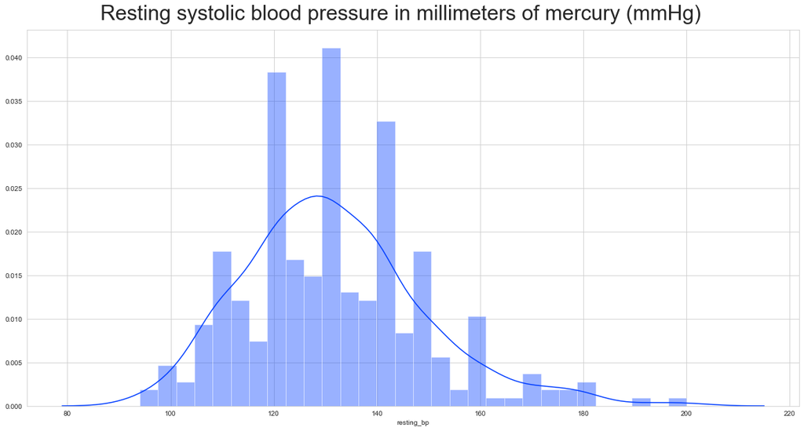

```python
plt.figure(figsize = (20,10))
sns.distplot(hd.resting_bp, bins = 30)
plt.figtext(.5,.9, 'Resting systolic blood pressure in millimeters of mercury (mmHg)', fontsize = 30, ha = 'center')
```

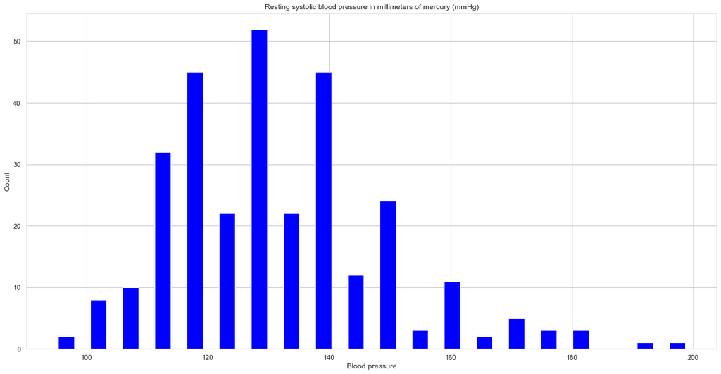

```python
plt.figure(figsize = (20,10))
plt.hist(hd.resting_bp, bins = 20, rwidth = 0.5, color = 'blue', align = 'mid')
plt.xlabel('Blood pressure')
plt.ylabel('Count')
plt.title('Resting systolic blood pressure in millimeters of mercury (mmHg)')
```

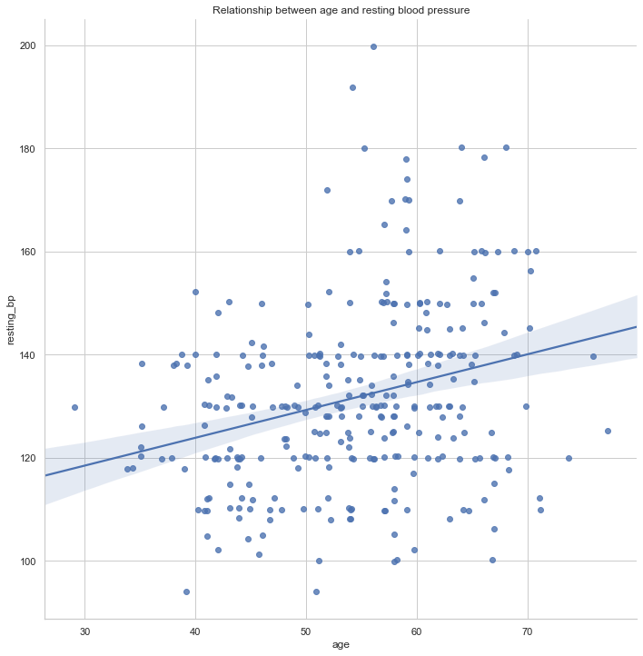

```python
sns.set_style('whitegrid')
sns.lmplot('age', 'resting_bp', data = hd, height = 10, x_jitter = 0.3, y_jitter = 0.3)
plt.title('Relationship between age and resting blood pressure')
```

| sex |  | age | resting_bp |
| --- | --- | --- | --- |
| F | age | 1.000000 | 0.313959 |
|  | resting_bp | 0.313959 | 1.000000 |
| M | age | 1.000000 | 0.254196 |
|  | resting_bp | 0.254196 | 1.000000 |

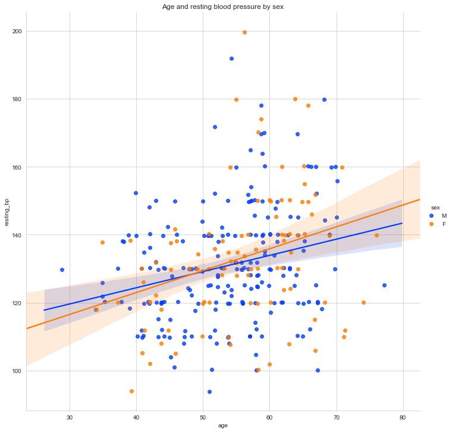

```python
sns.lmplot('age', 'resting_bp', data = hd, hue = 'sex', height = 10, x_jitter = 0.3, y_jitter = 0.3)
plt.title('Age and resting blood pressure by sex')

hd[['age', 'resting_bp']].corr()
hd.groupby('sex')[['age','resting_bp']].corr()
```

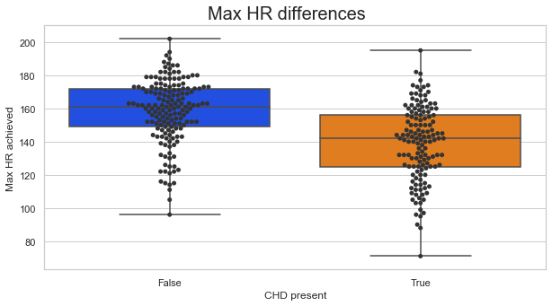

```python
plt.figure(figsize = (10,5))
ax = sns.boxplot(x = 'CHD_present', y = 'max_hr', data = hd, whis=np.inf)
ax = sns.swarmplot(x = 'CHD_present', y = 'max_hr', data = hd, color = '.2')
plt.figtext(.5,.9, 'Max HR differences', fontsize = 20, ha = 'center')
plt.xlabel('CHD present')
plt.ylabel('Max HR achieved')
```

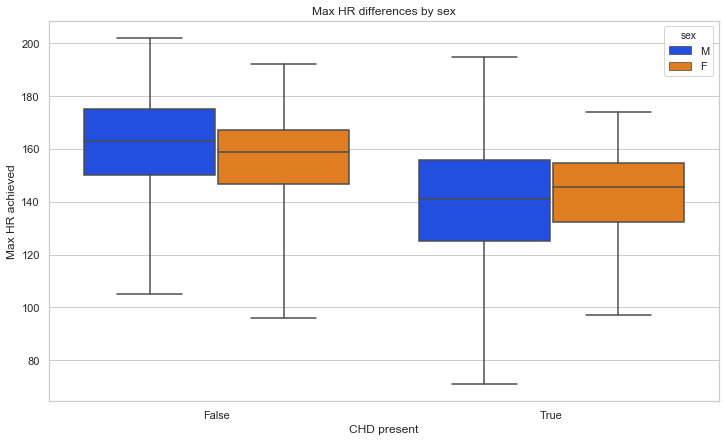

```python
plt.figure(figsize = (12, 7))
sns.boxplot(x = 'CHD_present', y = 'max_hr', data = hd, hue = 'sex', whis=np.inf)
plt.title('Max HR differences by sex')
plt.xlabel('CHD present')
plt.ylabel('Max HR achieved')
```

#### Achieving a higher max HR in the stress test was a fairly good indicator of whether someone had CHD or not.

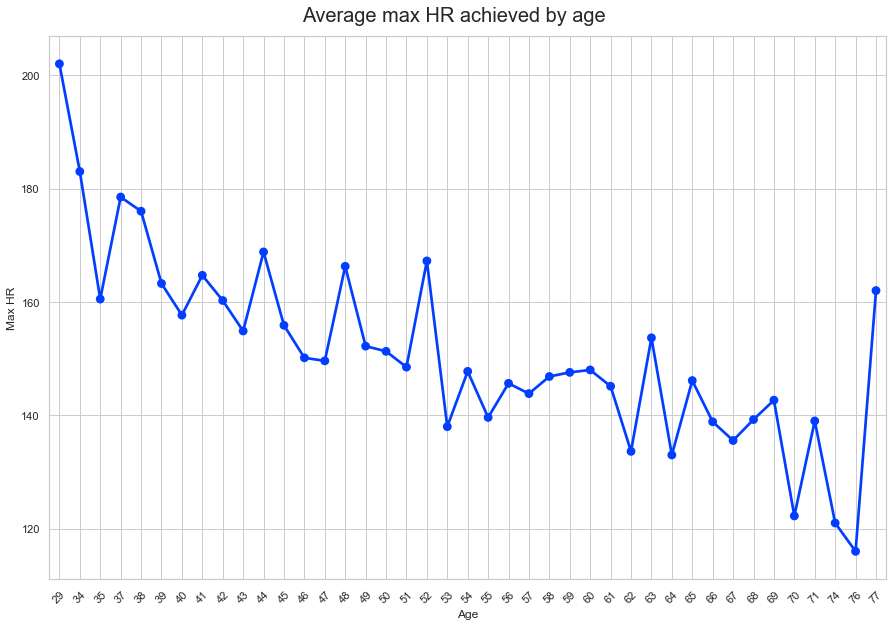

```python
average_max_hr = hd.groupby('age', as_index = False).max_hr.mean()
plt.figure(figsize = (15,10))
sns.pointplot(x = 'age', y = 'max_hr', data = average_max_hr)
plt.xticks(rotation = 45)
plt.grid(all)
plt.figtext(.5,.9, 'Average max HR achieved by age', fontsize = 20, ha = 'center')
plt.xlabel('Age')
plt.ylabel('Max HR')
```

|  | age | max_hr |
| --- | --- | --- |
| age | 1.000000 | -0.398522 |
| max_hr | -0.398522 | 1.000000 |

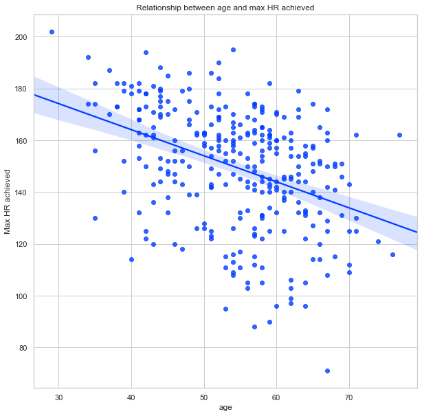

```python
plt.figure(figsize = (10,10))
sns.regplot('age', 'max_hr', data = hd)
plt.xlabel('age')
plt.ylabel('Max HR achieved')
plt.title('Relationship between age and max HR achieved')

hd[['age', 'max_hr']].corr()
```

```
CHD_present  exercise_angina
False        False              142
             True                23
True         True                76
             False               62
Name: exercise_angina, dtype: int64
CHD_present  exercise_angina
False        False              0.860606
             True               0.139394
True         True               0.550725
             False              0.449275
Name: exercise_angina, dtype: float64
```

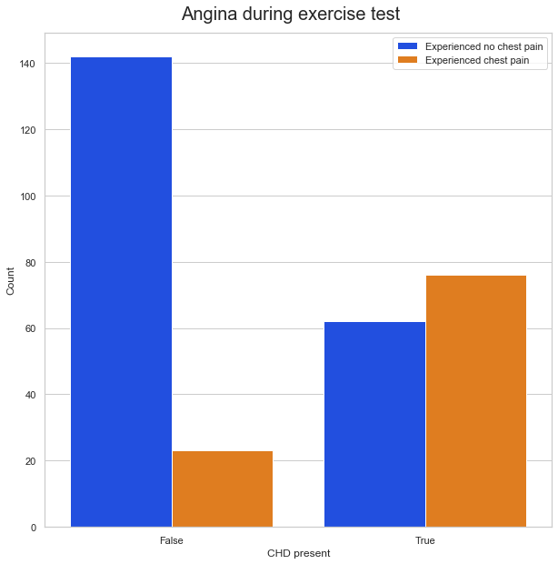

```python
plt.figure(figsize = (10,10))
sns.countplot(x = 'CHD_present', hue = 'exercise_angina', data = hd)
plt.legend(labels = ['Experienced no chest pain', 'Experienced chest pain'])
plt.figtext(.5,.9, 'Angina during exercise test', fontsize = 20, ha = 'center')
plt.xlabel('CHD present')
plt.ylabel('Count')

print(hd.groupby('CHD_present')['exercise_angina'].value_counts())
print(hd.groupby('CHD_present')['exercise_angina'].value_counts(normalize = True))
```

```
CHD_present  sex  exercise_angina
False        F    False              64
                  True                8
             M    False              78
                  True               15
True         F    False              10
                  True               14
             M    False              52
                  True               62
Name: exercise_angina, dtype: int64
CHD_present  sex  exercise_angina
False        F    False              0.888889
                  True               0.111111
             M    False              0.838710
                  True               0.161290
True         F    False              0.416667
                  True               0.583333
             M    False              0.456140
                  True               0.543860
Name: exercise_angina, dtype: float64
```

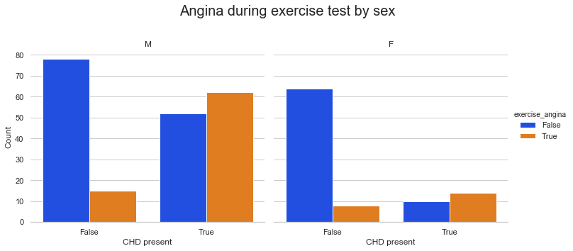

```python
g = sns.catplot(x = 'CHD_present', hue = 'exercise_angina', col = 'sex', data = hd, kind = 'count', legend = True)
(g.set_axis_labels('CHD present', 'Count')
 .set_titles('{col_name}')
 .despine(left = True))
plt.subplots_adjust(top=0.8)
g.fig.suptitle('Angina during exercise test by sex', fontsize = 20)

print(hd.groupby(['CHD_present', 'sex'])['exercise_angina'].value_counts().sort_index())
print(hd.groupby(['CHD_present', 'sex'])['exercise_angina'].value_counts(normalize = True).sort_index())
```

#### Exercise angina presented itself between 54% and 58% in males and females that have CHD

```
count    303.000000
mean       1.039604
std        1.161075
min        0.000000
25%        0.000000
50%        0.800000
75%        1.600000
max        6.200000
Name: ST_depression, dtype: float64
```

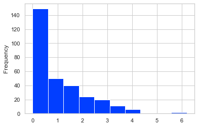

```python
hd.ST_depression.plot(kind = 'hist', bins = 10)
hd.ST_depression.describe()
```

```python
hd.loc[hd['ST_depression'] > 6.0]
```

|  | age | sex | chest_pain | resting_bp | cholesterol | fasting_bs | max_hr | exercise_angina | ST_depression | ST_slope | vessels_colored | defect | CHD_present |
| --- | --- | --- | --- | --- | --- | --- | --- | --- | --- | --- | --- | --- | --- |
| 204 | 62 | F | asymptomatic | 160 | 164 | False | 145 | False | 6.2 | upsloping | 3 | reversable_defect | True |

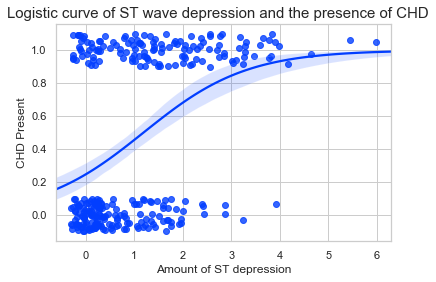

```python
sns.regplot('ST_depression', 'CHD_present', data = hd, logistic = True, x_jitter = 0.3, y_jitter = 0.1)
plt.xlabel('Amount of ST depression')
plt.ylabel('CHD Present')
plt.figtext(.5,.9, 'Logistic curve of ST wave depression and the presence of CHD', fontsize = 15, ha = 'center')
```

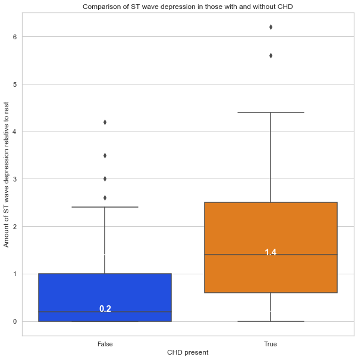

```python
plt.figure(figsize = (10,10))
STplot = sns.boxplot('CHD_present', 'ST_depression', data = hd)

m1 = hd.groupby(['CHD_present'])['ST_depression'].median().values
mL1 = [str(np.round(s, 2)) for s in m1]

ind = 0

for tick in range(len(testPlot.get_xticklabels())):
    STplot.text(tick, m1[ind+1], mL1[ind+1],  horizontalalignment='center',  color='w', weight='bold', fontsize = 15)
    STplot.text(tick, m1[ind], mL1[ind], horizontalalignment='center', color='w', weight='bold',fontsize = 15)


plt.xlabel('CHD present')
plt.ylabel('Amount of ST wave depression relative to rest')
plt.title('Comparison of ST wave depression in those with and without CHD')
plt.show()
```

| CHD_present | mean | median |
| --- | --- | --- |
| False | 0.363636 | 0 |
| True | 1.166667 | 1 |

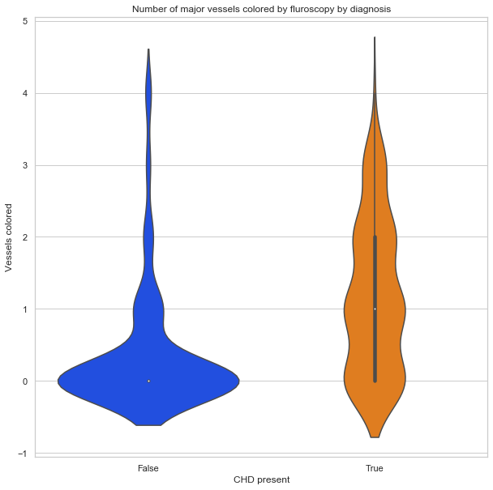

```python
plt.figure(figsize = (10,10))
sns.violinplot(x = 'CHD_present', y = 'vessels_colored', data = hd)
plt.figtext(.5, .9, 'Number of major vessels colored by fluroscopy by diagnosis')
plt.xlabel('CHD present')
plt.ylabel('Vessels colored')
hd.groupby('CHD_present')['vessels_colored'].agg(['mean', 'median'])
```

```python
print(hd.groupby('CHD_present')['ST_slope'].value_counts().sort_index())
print(hd.groupby('CHD_present')['ST_slope'].value_counts(normalize = True).sort_index())
```

[output not shown]

```
ST_slope     CHD_present
downsloping  False          107
             True            35
flat         False           49
             True            91
upsloping    False            9
             True            12
Name: CHD_present, dtype: int64
ST_slope     CHD_present
downsloping  False          0.753521
             True           0.246479
flat         False          0.350000
             True           0.650000
upsloping    False          0.428571
             True           0.571429
Name: CHD_present, dtype: float64
```

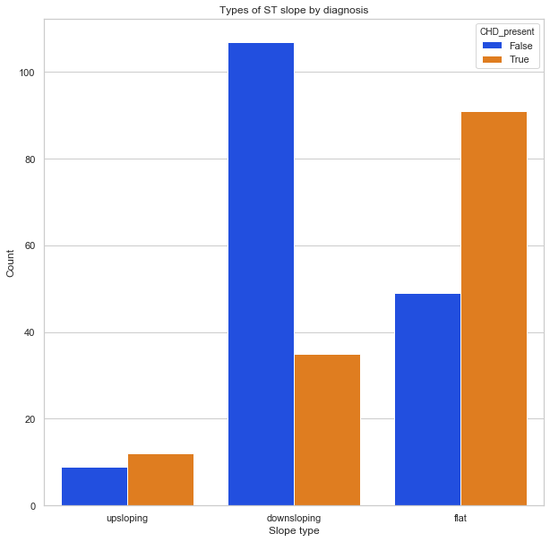

```python
plt.figure(figsize = (10,10))
sns.countplot(x = 'ST_slope', hue = 'CHD_present', data = hd)
plt.xlabel('Slope type')
plt.ylabel('Count')
plt.title('Types of ST slope by diagnosis')

print(hd.groupby('ST_slope')['CHD_present'].value_counts().sort_index())
print(hd.groupby('ST_slope')['CHD_present'].value_counts(normalize = True).sort_index())
```

#### Interestingly enough, the ST wave has predictive power as well. Those that have downsloping ST segments only have CHD approximately 25% of the time, where as those that had flat segments have CHD approximately 65% of the time.

```python
hd.groupby('defect')['CHD_present'].value_counts().sort_index()
```

```
defect             CHD_present
NaN                False            1
                   True             1
fixed_defect       False          130
                   True            36
normal             False            6
                   True            12
reversable_defect  False           28
                   True            89
Name: CHD_present, dtype: int64
```

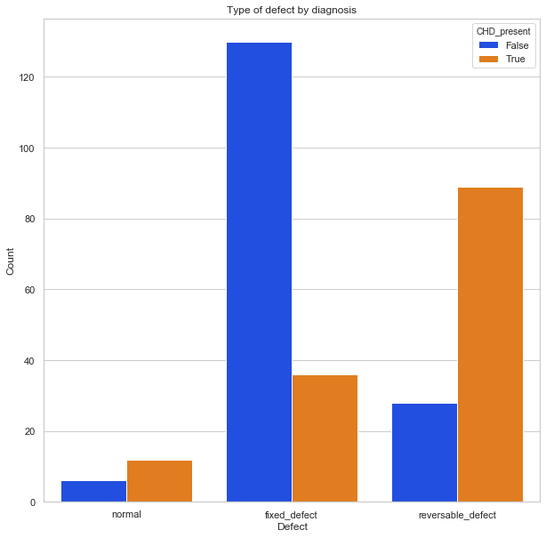

```python
plt.figure(figsize = (10,10))
sns.countplot('defect', hue = 'CHD_present', data = hd.loc[hd['defect'] != 'NaN'])
plt.xlabel('Defect')
plt.ylabel('Count')
plt.title('Type of defect by diagnosis')
```